# MPDW 6

Rahmandani

2025-10-01

#Import

```r
data_btc1 = read.csv("C:/Users/PC/Downloads/Harga btc_kelompok 10.csv")

data_btc= data_btc1[829:1656,]
head(data_btc)
```

```
##          date price
## 829  4/8/2013 187.5
## 830  4/9/2013 230.0
## 831 4/10/2013 165.0
## 832 4/11/2013 124.9
## 833 4/12/2013 117.0
## 834 4/13/2013  93.0
```

```r
library(ggplot2)
library(tsibble)
library(tseries)
library(MASS)
library(lubridate)
library(dplyr)
```

#Plot time series

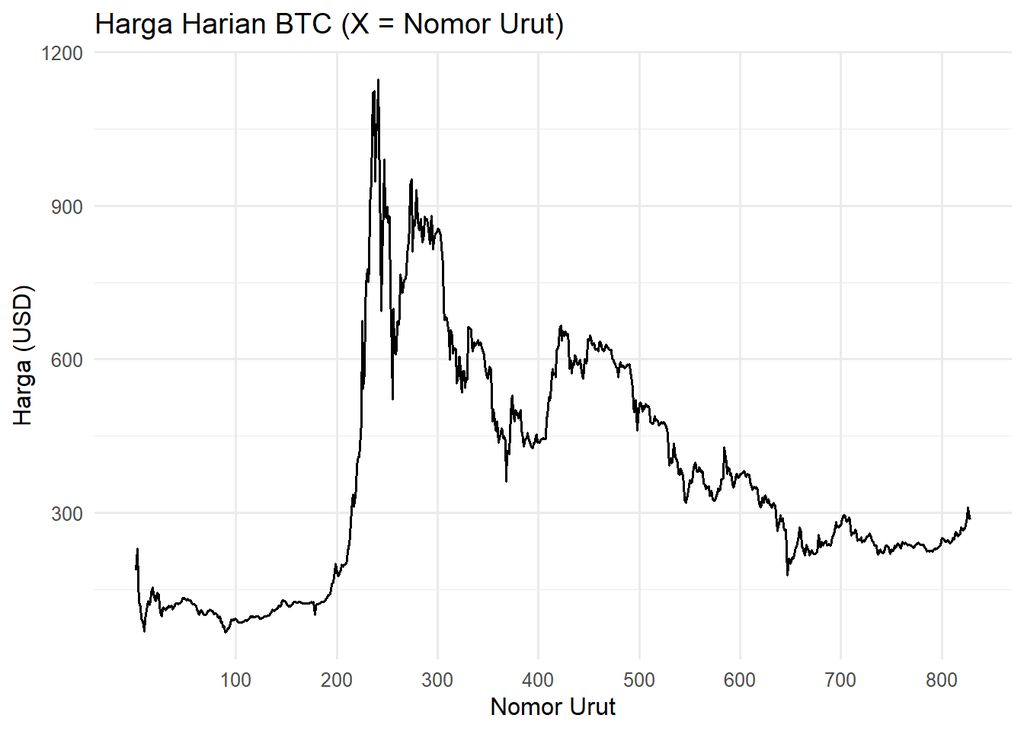

```r
btc = data_btc |>
  transmute(
    tanggal = mdy(date),
    tanggal = coalesce(tanggal, as.Date(date)),
    harga   = as.numeric(price)
  ) |>
  filter(!is.na(tanggal), !is.na(harga)) |>
  arrange(tanggal) |>
  distinct(tanggal, .keep_all = TRUE) |>
  mutate(indeks = row_number())

ggplot(btc, aes(x = indeks, y = harga)) +
  geom_line(linewidth = 0.6) +
  scale_x_continuous(
    breaks = seq(100, nrow(btc), by = 100),
    minor_breaks = NULL,
    limits = c(1, nrow(btc))
  ) +
  labs(x = "Nomor Urut", y = "Harga (USD)", title = "Harga Harian BTC (X = Nomor Urut)") +
  theme_minimal(base_size = 12)
```

##Hasil Plot time series Tidak stasioner dalam ragam karena memiliki lebar pita yang cenderung tidak sama

#Plot ACF

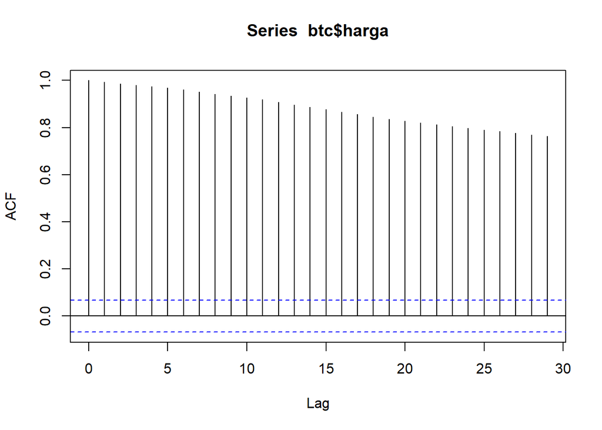

```r
acf(btc$harga)
```

##Hasil ACF Berdasarkan plot ACF, terlihat bahwa plot ACF pada data tersebut menurun secara perlahan (tails off slowly) yang menandakan data tidak stasioner dalam rataan #Uji ADF

```r
tseries::adf.test(btc$harga)
```

```
##
##  Augmented Dickey-Fuller Test
##
## data:  btc$harga
## Dickey-Fuller = -1.8525, Lag order = 9, p-value = 0.6407
## alternative hypothesis: stationary
```

##Hasil ADF Karena p-value > 0.05 maka tak tolak H0 dan menandakan bahwa data tidak stasioner dalam rataan

#box-cox

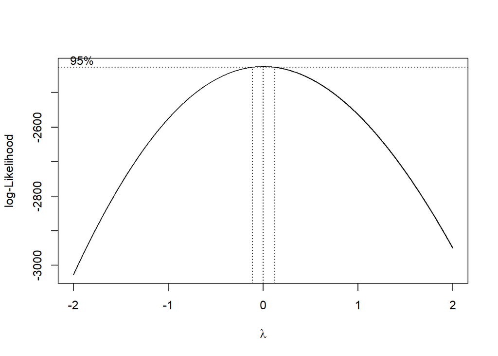

```r
library(MASS)

# Box-Cox
bc <- boxcox(
  harga ~ indeks,
  data   = btc,
  lambda = seq(-2, 2, by = 0.0001)
)
```

```r
# Lambda optimum
lambda <- bc$x[which.max(bc$y)]
lambda
```

```
## [1] 0.0013
```

```r
# Selang kepercayaan 95%
ci_lambda <- bc$x[bc$y > max(bc$y) - 0.5 * qchisq(0.95, 1)]
ci_lower  <- min(ci_lambda)
ci_upper  <- max(ci_lambda)

c(Lambda = round(lambda, 6),
  Batas_Bawah = round(ci_lower, 6),
  Batas_Atas  = round(ci_upper, 6))
```

```
##      Lambda Batas_Bawah  Batas_Atas
##      0.0013     -0.1132      0.1164
```

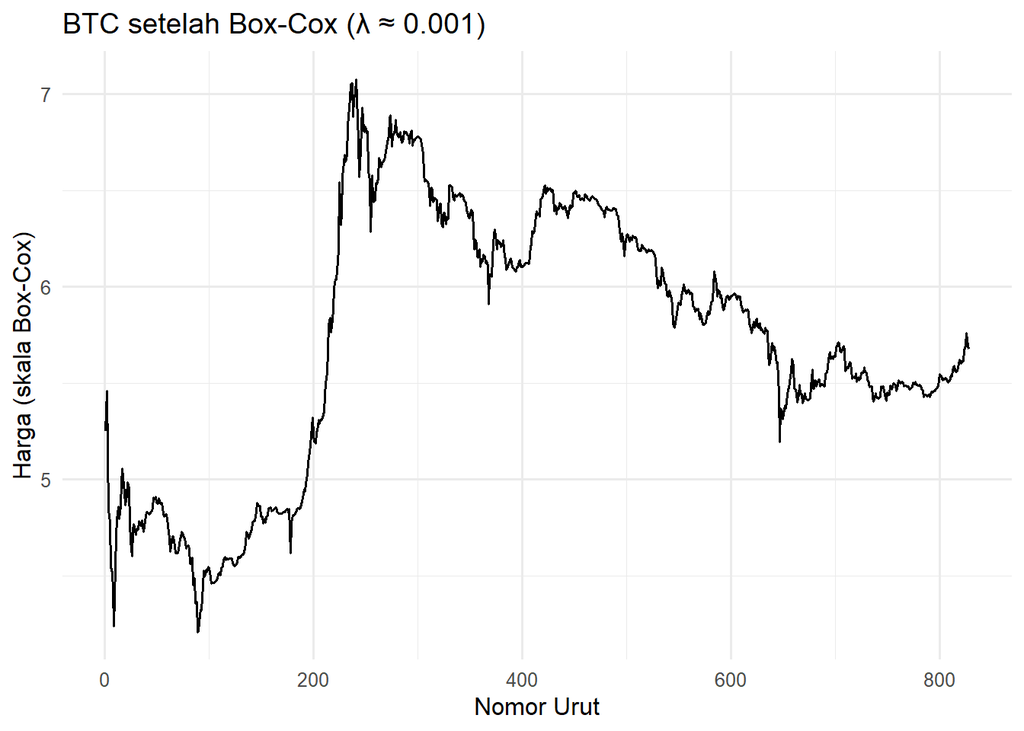

```r
boxcoxF = function(x, lam) if (abs(lam) < 1e-8) log(x) else (x^lam - 1) / lam

btcBox = btc %>%
  mutate(
    hargaBox = boxcoxF(harga, lambda),
    diff1    = dplyr::lag(hargaBox, default = NA),
    hargaBoxDiff = c(NA, diff(hargaBox, lag = 1))
  )

#  Plot deret hasil Box-Cox
ggplot(btcBox, aes(x = indeks, y = hargaBox)) +
  geom_line(linewidth = 0.6) +
  labs(title = paste0("BTC setelah Box-Cox (λ ≈ ", round(lambda, 3), ")"),
       x = "Nomor Urut", y = "Harga (skala Box-Cox)") +
  theme_minimal(base_size = 12)
```

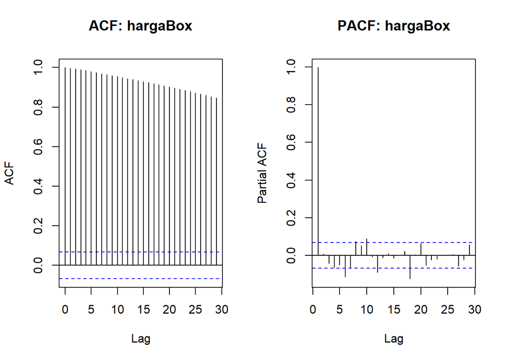

```r
# -ACF & PACF
par(mfrow = c(1,2))
acf(btcBox$hargaBox, na.action = na.omit, main = "ACF: hargaBox")
pacf(btcBox$hargaBox, na.action = na.omit, main = "PACF: hargaBox")
```

```r
par(mfrow = c(1,1))

#  Uji ADF
adf_level = adf.test(na.omit(btcBox$hargaBox), alternative = "stationary")
print(adf_level)
```

```
##
##  Augmented Dickey-Fuller Test
##
## data:  na.omit(btcBox$hargaBox)
## Dickey-Fuller = -1.3532, Lag order = 9, p-value = 0.8521
## alternative hypothesis: stationary
```

##Hasil boxcox Karena selang tersebut tidak memuat nilai λ = 1, maka dapat disimpulkan bahwa data tidak stasioner dalam ragam sehingga diperlukan transformasi.

##Hasil Setelah transformasi Boxcox Setelah melakukan transformasi boxcox data masih menunjukan bahwa data tidak stasioner dalam ragam dan rataan yang bisa diketahui dengan melihad adf test, plot time series dan acf

##Differensing hasil transformasi boxcox

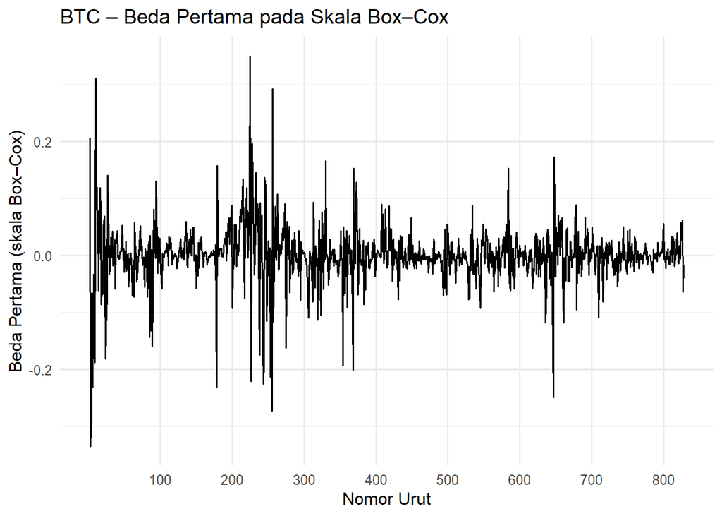

```r
seriDiff = diff(btcBox$hargaBox, differences = 1)


btcBoxDiff = data.frame(
  indeks       = btc$indeks[-1],
  hargaBoxDiff = seriDiff
)


library(ggplot2)
ggplot(btcBoxDiff, aes(indeks, hargaBoxDiff)) +
  geom_line(linewidth = 0.6) +
  scale_x_continuous(breaks = seq(100, max(btcBoxDiff$indeks), by = 100), minor_breaks = NULL) +
  labs(title = "BTC – Beda Pertama pada Skala Box–Cox",
       x = "Nomor Urut", y = "Beda Pertama (skala Box–Cox)") +
  theme_minimal(base_size = 12)
```

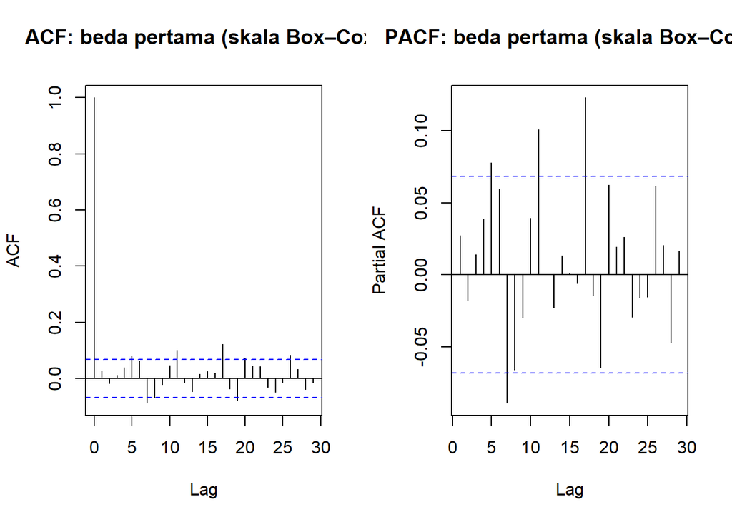

```r
par(mfrow = c(1,2))
acf(btcBoxDiff$hargaBoxDiff, main = "ACF: beda pertama (skala Box–Cox)")
pacf(btcBoxDiff$hargaBoxDiff, main = "PACF: beda pertama (skala Box–Cox)")
```

```r
par(mfrow = c(1,1))


library(tseries)
adf_diff = adf.test(btcBoxDiff$hargaBoxDiff, alternative = "stationary")
print(adf_diff)
```

```
##
##  Augmented Dickey-Fuller Test
##
## data:  btcBoxDiff$hargaBoxDiff
## Dickey-Fuller = -8.8789, Lag order = 9, p-value = 0.01
## alternative hypothesis: stationary
```

```r
if (adf_diff$p.value <= 0.05) {
  cat("KESIMPULAN: Beda pertama pada skala Box–Cox sudah stasioner (p ≤ 0.05).\n")
} else {
  cat("KESIMPULAN: Belum stasioner; pertimbangkan differencing tambahan / komponen musiman.\n")
}
```

```
## KESIMPULAN: Beda pertama pada skala Box–Cox sudah stasioner (p ≤ 0.05).
```

```r
length(btcBox$hargaBox)
```

```
## [1] 828
```

```r
sum(is.na(btcBox$hargaBox))
```

```
## [1] 0
```

```r
length(btcBox$hargaBoxDiff)
```

```
## [1] 828
```

```r
sum(is.na(btcBox$hargaBoxDiff))
```

```
## [1] 1
```

```r
x = btcBox$hargaBox
x = x[is.finite(x)]

if (length(x) < 2) stop("Data terlalu sedikit untuk differencing (butuh ≥ 2 observasi).")

seriDiff = diff(x, differences = 1)




y_pos = seriDiff + 10
if (min(y_pos, na.rm = TRUE) <= 0) y_pos = y_pos - min(y_pos, na.rm = TRUE) + 1e-6

if (length(y_pos) < 2) stop("Setelah pembersihan, seri untuk cek lambda masih < 2 observasi.")

df = data.frame(y_pos = y_pos, idx = seq_along(y_pos))
bc = MASS::boxcox(y_pos ~ idx, data = df, lambda = seq(-2, 2, by = 0.0001), plotit = FALSE)

lambda  = bc$x[which.max(bc$y)]
cutoff  = max(bc$y) - 0.5 * qchisq(0.95, 1)
ci_95   = range(bc$x[bc$y >= cutoff])

c(Lambda = round(lambda, 6),
  Batas_Bawah = round(ci_95[1], 6),
  Batas_Atas  = round(ci_95[2], 6),
  N = length(y_pos))
```

```
##      Lambda Batas_Bawah  Batas_Atas           N
##      2.0000     -0.0445      2.0000    827.0000
```

###Hasil Boxcox +differensing Uji adf, plot acf, dan lambda menunjukan bahwa data termasuk stasioner setelah diterapkan transformasi boxcox+diferensing ordo 1

#Diferencing data saja

```r
dtRg_diff1 <- diff(btc$harga, differences = 1)
indeks     <- seq_along(dtRg_diff1)


mask_pos <- dtRg_diff1 > 0
if (sum(mask_pos) < 10) warning("Nilai positif terlalu sedikit untuk profiling lambda yang stabil.")

bc <- boxcox(
  dtRg_diff1[mask_pos] ~ indeks[mask_pos],
  lambda = seq(0, 5, by = 0.001),
  plotit = FALSE
)
lambda_hat <- bc$x[which.max(bc$y)]
ci_lambda  <- bc$x[bc$y > max(bc$y) - 0.5 * qchisq(0.95, 1)]
cat("Lambda (cek saja) =", round(lambda_hat, 6),
    "; CI95%: [", round(min(ci_lambda), 6), ",", round(max(ci_lambda), 6), "]\n")
```

```
## Lambda (cek saja) = 0.09 ; CI95%: [ 0.042 , 0.14 ]
```

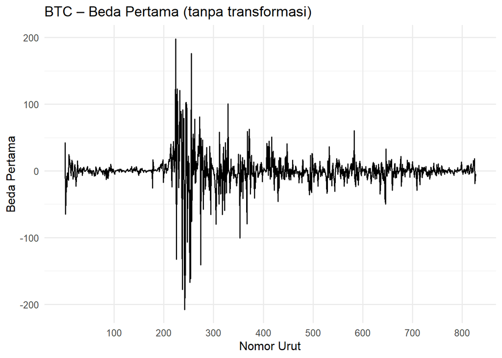

```r
btcDiff <- data.frame(
  indeks    = indeks,
  hargaDiff = dtRg_diff1
)


ggplot(btcDiff, aes(indeks, hargaDiff)) +
  geom_line(linewidth = 0.6) +
  scale_x_continuous(breaks = seq(100, max(btcDiff$indeks), by = 100), minor_breaks = NULL) +
  labs(title = "BTC – Beda Pertama (tanpa transformasi)",
       x = "Nomor Urut", y = "Beda Pertama") +
  theme_minimal(base_size = 12)
```

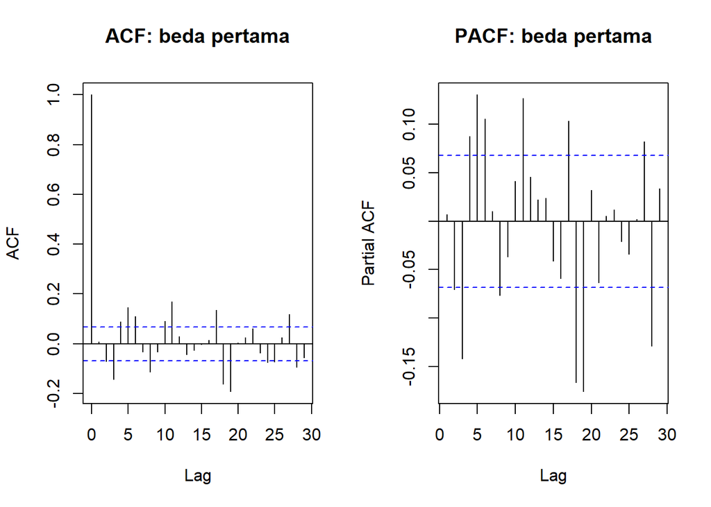

```r
par(mfrow = c(1,2))
acf(btcDiff$hargaDiff, main = "ACF: beda pertama")
pacf(btcDiff$hargaDiff, main = "PACF: beda pertama")
```

```r
par(mfrow = c(1,1))

adf_res <- adf.test(btcDiff$hargaDiff, alternative = "stationary")
print(adf_res)
```

```
##
##  Augmented Dickey-Fuller Test
##
## data:  btcDiff$hargaDiff
## Dickey-Fuller = -8.3558, Lag order = 9, p-value = 0.01
## alternative hypothesis: stationary
```

```r
# Ringkas
if (adf_res$p.value <= 0.05) {
  cat("KESIMPULAN: Beda pertama sudah stasioner (p ≤ 0.05).\n")
} else {
  cat("KESIMPULAN: Beda pertama belum stasioner (p > 0.05). Pertimbangkan differencing tambahan / musiman.\n")
}
```

```
## KESIMPULAN: Beda pertama sudah stasioner (p ≤ 0.05).
```

```r
#CEK boxcox lambda


beda1   = diff(btc$harga, differences = 1)
indeks  = seq_along(beda1)


beda1geser = beda1 + 220


bc = boxcox(
  beda1geser ~ indeks,
  lambda = seq(-2, 2, by = 0.001),
  plotit = FALSE
)


lambda  = bc$x[which.max(bc$y)]
batas   = max(bc$y) - 0.5 * qchisq(0.95, 1)
ci      = range(bc$x[bc$y >= batas])

c(
  Lambda = round(lambda, 6),
  CI95_bawah = round(ci[1], 6),
  CI95_atas  = round(ci[2], 6)
)
```

```
##     Lambda CI95_bawah  CI95_atas
##      1.442      1.300      1.590
```

##Hasil diferensing saja Berdasarkan uji adf data sudah stasioner dalam rataan namun jika melihat nilai lambda yang belum memuat 1 maka belum stasioner dalam ragam.

#Hasil Data btc pada awalnya tidak stasioner dalam ragam dan rataan. Setelah menerapkan transformasi boxcox dan melakukan differensing ordo 1 didapatkan data yang stasioner dalam ragam dan rataan. Saat mencoba melakukan differensing saja data hanya stasioner dalam rataan dan tidak dalam ragam